# **Problem Statement**

## **Business Context**

Workplace safety in hazardous environments like construction sites and industrial plants is crucial to prevent accidents and injuries. One of the most important safety measures is ensuring workers wear safety helmets, which protect against head injuries from falling objects and machinery. Non-compliance with helmet regulations increases the risk of serious injuries or fatalities, making effective monitoring essential, especially in large-scale operations where manual oversight is prone to errors and inefficiency.

To overcome these challenges, SafeGuard Corp plans to develop an automated image analysis system capable of detecting whether workers are wearing safety helmets. This system will improve safety enforcement, ensuring compliance and reducing the risk of head injuries. By automating helmet monitoring, SafeGuard aims to enhance efficiency, scalability, and accuracy, ultimately fostering a safer work environment while minimizing human error in safety oversight.

## **Objective**

As a data scientist at SafeGuard Corp, you are tasked with developing an image classification model that classifies images into one of two categories:

- **With Helmet:** Workers wearing safety helmets.
- **Without Helmet:** Workers not wearing safety helmets.

## **Data Description**

The dataset consists of **4125 images**, divided into two categories:

- **With Helmet:** 3161 images showing workers wearing helmets.
- **Without Helmet:** 964 images showing workers not wearing helmets.

**Dataset Characteristics:**

- **Variations in Conditions:** Images include diverse environments such as construction sites, factories, and industrial settings, with variations in lighting, angles, and worker postures to simulate real-world conditions.
- **Worker Activities:** Workers are depicted in different actions such as standing, using tools, or moving, ensuring robust model learning for various scenarios.

# **Please read the instructions carefully before starting the project.**

This is a commented Python Notebook file in which all the instructions and tasks to be performed are mentioned.

- Blanks '_____' are provided in the notebook that needs to be filled with an appropriate code to get the correct result. With every '_____' blank, there is a comment that briefly describes what needs to be filled in the blank space.
- Identify the task to be performed correctly, and only then proceed to write the required code.
- Please run the codes in a sequential manner from the beginning to avoid any unnecessary errors.
- Add the results/observations (wherever mentioned) derived from the analysis in the presentation and submit the same. Any mathematical or computational details which are a graded part of the project can be included in the Appendix section of the presentation.

# **Installing and Importing the Necessary Libraries**

```python
#!pip install tensorflow[and-cuda]==2.19.0 scikit-learn==1.6.1 opencv-python==4.12.0.88 seaborn==0.13.2 matplotlib==3.10.0 numpy==2.0.2 pandas==2.2.2 -q
```

**Note:**

- After running the above cell, kindly restart the notebook kernel (for Jupyter Notebook) or runtime (for Google Colab) and run all cells sequentially from the next cell.
- On executing the above line of code, you might see a warning regarding package dependencies. This error message can be ignored as the above code ensures that all necessary libraries and their dependencies are maintained to successfully execute the code in this notebook.

```python
import os
import random
import numpy as np
import pandas as pd
import seaborn as sns
import matplotlib.image as mpimg
import matplotlib.pyplot as plt
import math
import cv2


# Tensorflow modules
import keras
import tensorflow as tf
from tensorflow.keras.preprocessing.image import ImageDataGenerator
from tensorflow.keras.models import Sequential
from tensorflow.keras.layers import Dense,Dropout,Flatten,Conv2D,MaxPooling2D,BatchNormalization
from tensorflow.keras.optimizers import Adam,SGD
from sklearn import preprocessing
from sklearn.model_selection import train_test_split
from sklearn.metrics import confusion_matrix
from tensorflow.keras.models import Model
from keras.applications.vgg16 import VGG16

# Display images using OpenCV
from google.colab.patches import cv2_imshow

#Imports functions for evaluating the performance of machine learning models
from sklearn.metrics import confusion_matrix, f1_score,accuracy_score, recall_score, precision_score, classification_report
from sklearn.metrics import mean_squared_error as mse

# Ignore warnings
import warnings
warnings.filterwarnings('ignore')
```

```python
print("Num GPUs Available:", len(tf.config.list_physical_devices('GPU')))
```

```
Num GPUs Available: 1
```

```python
# 1. Set Python random seed
random.seed(812)

# 2. Set NumPy random seed
np.random.seed(812)

# 3. Set TensorFlow seed (covers Keras + backend)
tf.keras.utils.set_random_seed(812)

# 4. Enable deterministic GPU ops (if using GPU)
tf.config.experimental.enable_op_determinism()
```

# **Data Overview**

## Loading the data

```python
# Uncomment and run the following code in case Google Colab is being used
from google.colab import drive
drive.mount('/content/drive')
```

```python
PROJECT_DIR = "/content/drive/MyDrive/Computer Vision Project/HelmNet_Project/"

images_path = os.path.join(PROJECT_DIR, "images.npy")
labels_path = os.path.join(PROJECT_DIR, "labels-2.csv")

images = np.load(images_path)
labels = pd.read_csv(labels_path)
```

```python
import os

print("Current folder:", os.getcwd())
print("Files in current folder:")
print(os.listdir())
```

```
Current folder: /content
Files in current folder:
['.config', 'drive', 'sample_data']
```

```python
from pathlib import Path

drive_root = Path("/content/drive/MyDrive/Computer Vision Project")

image_matches = list(drive_root.rglob("images.npy"))
label_matches = list(drive_root.rglob("labels-2.csv"))

print("images.npy locations:")
for path in image_matches:
    print(path)

print("\nlabels-2.csv locations:")
for path in label_matches:
    print(path)
```

```
images.npy locations:
/content/drive/MyDrive/Computer Vision Project/images.npy
/content/drive/MyDrive/Computer Vision Project/HelmNet_Project/images.npy

labels-2.csv locations:
/content/drive/MyDrive/Computer Vision Project/labels-2.csv
/content/drive/MyDrive/Computer Vision Project/HelmNet_Project/labels-2.csv
```

```python
images_path = (
    "/content/drive/MyDrive/"
    "Computer Vision Project/HelmNet_Project/images.npy"
)

labels_path = (
    "/content/drive/MyDrive/"
    "Computer Vision Project/HelmNet_Project/labels-2.csv"
)

images = np.load(images_path)
labels = pd.read_csv(labels_path)

print("Images loaded successfully:", images.shape)
print("Labels loaded successfully:", labels.shape)

print("\nLabel counts:")
print(labels["label"].value_counts().sort_index())
```

```
Images loaded successfully: (4125, 200, 200, 3)
Labels loaded successfully: (4125, 1)

Label counts:
label
0     964
1    3161
Name: count, dtype: int64
```

```python
images = np.load(
    "/content/drive/MyDrive/Computer Vision Project/"
    "HelmNet_Project/images.npy"
)

labels = pd.read_csv(
    "/content/drive/MyDrive/Computer Vision Project/"
    "HelmNet_Project/labels-2.csv"
)
```

```python
print(images.shape) #Complete the code to print the shape of the images
print(labels.shape) #Complete the code to print the shape of the labels
```

```
(4125, 200, 200, 3)
(4125, 1)
```

# **Exploratory Data Analysis**

### Plot random images from each of the classes and print their corresponding labels.

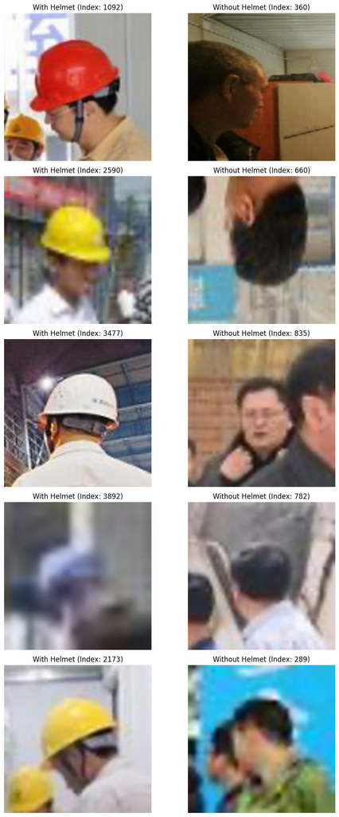

```python
# Get indices for 'With Helmet' (label 1) and 'Without Helmet' (label 0)
helmet_indices = labels[labels.iloc[:, 0] == 1].index.tolist()
no_helmet_indices = labels[labels.iloc[:, 0] == 0].index.tolist()

# Select 5 random indices from each class
num_samples_to_plot = 5
random_helmet_idxs = random.sample(helmet_indices, num_samples_to_plot)
random_no_helmet_idxs = random.sample(no_helmet_indices, num_samples_to_plot)

fig, axes = plt.subplots(num_samples_to_plot, 2, figsize=(10, 4 * num_samples_to_plot))

for i in range(num_samples_to_plot):
    # Plot 'With Helmet' images
    axes[i][0].imshow(images[random_helmet_idxs[i]])
    axes[i][0].set_title(f"With Helmet (Index: {random_helmet_idxs[i]})")
    axes[i][0].axis("off")

    # Plot 'Without Helmet' images
    axes[i][1].imshow(images[random_no_helmet_idxs[i]])
    axes[i][1].set_title(f"Without Helmet (Index: {random_no_helmet_idxs[i]})")
    axes[i][1].axis("off")

plt.tight_layout()
plt.show()
```

## Exploratory Data Analysis: Random Image Samples

This visualization provides an exploratory check of the image data. It helps confirm that the images and labels were loaded correctly and that the two classes generally represent their intended categories.

### How to Read the Display

- The **left column** contains randomly selected images labeled `1`, meaning **With Helmet**.
- The **right column** contains randomly selected images labeled `0`, meaning **Without Helmet**.
- The index displayed in each title identifies the image's position in the dataset. It is not a model prediction or performance score.
- Five images were randomly selected from each class.

For example:

- **With Helmet (Index: 1092)** means that image `1092` has a true label of `1`.
- **Without Helmet (Index: 360)** means that image `360` has a true label of `0`.

### What the Code Does

The following line identifies the positions of all images labeled `1`:

```
helmet_indices = labels[labels.iloc[:, 0] == 1].index.tolist()
```

The following line identifies the positions of all images labeled `0`:

```
no_helmet_indices = labels[labels.iloc[:, 0] == 0].index.tolist()
```

The following command randomly selects five images from the helmet class:

```
random.sample(helmet_indices, 5)
```

The same process is used to select five images from the no-helmet class. The loop then displays the selected images in two columns for visual comparison.

### Observations

The sampled images suggest that the class labels are generally reasonable:

- Workers in the left column are wearing visible red, yellow, or white safety helmets.
- People in the right column generally have uncovered heads rather than safety helmets.
- The dataset includes front, side, and rear views of workers.
- Helmet colors, shapes, and visibility vary.
- The size and location of each person's head vary considerably.
- Some images contain more than one person.
- Lighting conditions and backgrounds vary across the dataset.
- Several images are blurred, low-resolution, partially obstructed, or poorly framed.
- Some workers occupy only a small portion of the image.

The helmet image at index `3892` is particularly blurred, making the helmet difficult to distinguish. Some no-helmet images are also blurred or partially obstructed. These difficult examples could increase classification errors.

### Important Interpretation

This visualization does **not** demonstrate that a model is accurate because no model has been trained or evaluated yet. It only helps confirm that:

1. The image array and label file appear to be correctly aligned.
2. Label `1` represents **With Helmet**.
3. Label `0` represents **Without Helmet**.
4. The dataset contains considerable visual variability.
5. Some images may be difficult even for a human to classify.

### Overall EDA Conclusion

The sampled images confirm that label `1` represents workers wearing safety helmets and label `0` represents workers without safety helmets. The dataset contains substantial variation in helmet color, worker position, head orientation, lighting, background, image sharpness, and camera distance.

Several images are blurred, partially obstructed, or contain small subjects, which may make classification difficult. This variability reflects realistic image conditions, but it may also increase model error—particularly when a worker's head or helmet is not clearly visible.

### Concise Observation for the Presentation

Random samples confirmed the intended class definitions. The images vary considerably in lighting, viewing angle, subject size, background, and sharpness. Blurred and partially obstructed images represent challenging classification cases and may reduce model performance.

## Checking for class imbalance

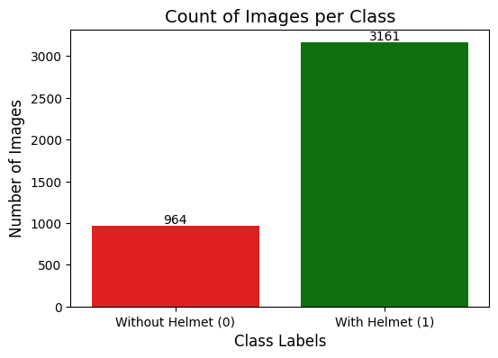

```python
# Create a count plot
plt.figure(figsize=(6, 4))
ax = sns.countplot(x=labels.iloc[:, 0], palette=['red', 'green'])

# Add exact counts on top of bars
for p in ax.patches:
    ax.annotate(f'{int(p.get_height())}', (p.get_x() + p.get_width() / 2, p.get_height()),
                ha='center', va='bottom', fontsize=10, )

# Add labels
plt.xlabel("Class Labels", fontsize=12)
plt.ylabel("Number of Images", fontsize=12)
plt.title("Count of Images per Class", fontsize=14)
plt.xticks(ticks=[0, 1], labels=["Without Helmet (0)", "With Helmet (1)"])  # Rename x-axis labels

# Show plot
plt.show()
```

## Exploratory Data Analysis: Class Distribution

This count plot shows the number of images belonging to each target class in the dataset.

### How to Read the Chart

- The red bar represents images labeled `0`, meaning **Without Helmet**.
- The green bar represents images labeled `1`, meaning **With Helmet**.
- The number above each bar is the exact number of images in that class.

The dataset contains:

- **964 images without helmets**
- **3,161 images with helmets**
- **4,125 total images**

### Class Percentages

The percentage of images in each class is calculated as:

$$ \text{Class Percentage} = \frac{\text{Number of Images in the Class}} {\text{Total Number of Images}} \times 100 $$

For the **Without Helmet** class:

$$ \frac{964}{4125}\times 100 \approx 23.4\% $$

For the **With Helmet** class:

$$ \frac{3161}{4125}\times 100 \approx 76.6\% $$

Therefore:

- **Without Helmet (`0`): approximately 23.4%**
- **With Helmet (`1`): approximately 76.6%**

There are approximately:

$$ \frac{3161}{964}\approx3.28 $$

times as many helmet images as no-helmet images. Therefore:

- **Without Helmet (`0`): approximately 23.4%**
- **With Helmet (`1`): approximately 76.6%**

There are approximately **3.28 times as many helmet images as no-helmet images**.

### What the Code Does

The following statement creates a figure measuring 6 inches wide by 4 inches high:

```
plt.figure(figsize=(6, 4))
```

The following command counts the number of examples associated with each label and displays the results as bars:

```
ax = sns.countplot(
    x=labels.iloc[:, 0],
    palette=["red", "green"]
)
```

In this expression, `labels.iloc[:, 0]` selects every row from the first column of the labels DataFrame.

The following loop places the exact class count above each bar:

```
for p in ax.patches:
    ax.annotate(
        f"{int(p.get_height())}",
        (
            p.get_x() + p.get_width() / 2,
            p.get_height()
        ),
        ha="center",
        va="bottom",
        fontsize=10
    )
```

The remaining commands add the chart title, axis labels, and descriptive class names.

### Observations

The chart reveals a noticeable class imbalance:

- The **With Helmet** class is the majority class.
- The **Without Helmet** class is the minority class.
- More than three-quarters of the images belong to the helmet class.
- Less than one-quarter belong to the no-helmet class.

This imbalance could cause a model to favor the majority class. For example, a model that predicted **With Helmet** for every image would obtain approximately **76.6% accuracy**, even though it would fail to identify every unsafe no-helmet case.

Therefore, accuracy alone will not provide an adequate evaluation of model performance.

### Modeling Implications

The data should be divided using a **stratified split** so that the training, validation, and test sets preserve approximately the same class proportions.

Model performance should be evaluated using multiple measures, including:

- **Macro precision**
- **Macro recall**
- **Macro F1-score**
- **Confusion matrix**
- **Recall for the Without Helmet class**
- **Recall for the With Helmet class**

Recall for the **Without Helmet** class is particularly important because failing to detect a worker without a helmet could allow an unsafe condition to go unaddressed.

A standard binary recall metric usually treats label `1` as the positive class. In this dataset, label `1` means **With Helmet**. Therefore, standard recall for label `1` does not directly measure the model's ability to detect unsafe no-helmet cases. Class-specific recall and the confusion matrix should also be examined.

### Overall EDA Conclusion

The dataset is imbalanced, with 3,161 helmet images and 964 no-helmet images. The helmet class accounts for approximately 76.6% of the dataset, while the no-helmet class accounts for approximately 23.4%.

This imbalance must be considered when splitting the data, training the models, and evaluating performance. The final model should not be selected based only on accuracy. Particular attention should be given to macro F1-score and the model's ability to correctly identify workers who are not wearing helmets.

### Concise Observation for the Presentation

The dataset contains 4,125 images: 3,161 with helmets (76.6%) and 964 without helmets (23.4%). This class imbalance could cause a model to favor the majority helmet class. Model selection should therefore consider macro precision, macro recall, macro F1-score, confusion matrices, and no-helmet recall rather than accuracy alone.

# **Data Preprocessing**

### Splitting the dataset

```python
X_train, X_temp, y_train, y_temp = train_test_split(np.array(images),labels , test_size=0.20, random_state=42,stratify=labels) #Complete the code to define the test_size
X_val, X_test, y_val, y_test = train_test_split(X_temp,y_temp , test_size=0.50, random_state=42,stratify=y_temp) #Complete the code to define the test_size
```

```python
print(X_train.shape,y_train.shape) #Complete the code to print the shape of the train data
print(X_val.shape,y_val.shape) #Complete the code to print the shape of the validation data
print(X_test.shape,y_test.shape) #Complete the code to print the shape of the test data
```

```
(3300, 200, 200, 3) (3300, 1)
(412, 200, 200, 3) (412, 1)
(413, 200, 200, 3) (413, 1)
```

### Data Normalization

Since the **image pixel values range from 0-255**, our method of normalization here will be **scaling** - we shall **divide all the pixel values by 255 to standardize the images to have values between 0-1.**

```python
X_train_normalized = X_train.astype('float32')/255.0 #Complete the code to normalize the training images
X_val_normalized = X_val.astype('float32')/255.0  #Complete the code to normalize the validation images
X_test_normalized = X_test.astype('float32')/255.0   #Complete the code to normalize the test images
```

```python
print(
    "Training range:",
    X_train_normalized.min(),
    "to",
    X_train_normalized.max()
)

print(
    "Validation range:",
    X_val_normalized.min(),
    "to",
    X_val_normalized.max()
)

print(
    "Test range:",
    X_test_normalized.min(),
    "to",
    X_test_normalized.max()
)
```

```
Training range: 0.0 to 1.0
Validation range: 0.0 to 1.0
Test range: 0.0 to 1.0
```

## Data Preprocessing Results and Interpretation

### Dataset Split Results

The original dataset of **4,125 images** was divided into training, validation, and test datasets.

The resulting shapes are:

```
Training:   (3300, 200, 200, 3)  (3300, 1)
Validation: (412, 200, 200, 3)   (412, 1)
Test:       (413, 200, 200, 3)   (413, 1)
```

The image-array shapes follow this structure:

```
(number of images, image height, image width, color channels)
```

Therefore:

- The training dataset contains **3,300 images**.
- The validation dataset contains **412 images**.
- The test dataset contains **413 images**.
- Every image is **200 pixels high and 200 pixels wide**.
- Every image has **three color channels** representing red, green, and blue.

The label-array shapes show that each image has one corresponding binary label:

- Label `0`: **Without Helmet**
- Label `1`: **With Helmet**

The number of labels matches the number of images in each subset, confirming that the images and labels remained correctly aligned during the split.

### Approximate Split Percentages

The dataset was divided into approximately:

- **80% training data**
- **10% validation data**
- **10% test data**

The validation and test datasets differ by one image because 825 temporary images cannot be divided evenly into two groups of whole images.

### Purpose of the Three Datasets

- The **training dataset** is used to teach the model and update its weights.
- The **validation dataset** is used to evaluate models during development, detect overfitting, and select the best model.
- The **test dataset** is reserved for the final evaluation of the selected model on unseen data.

The test data should not be used to choose between models because this could cause information leakage and lead to an overly optimistic performance estimate.

### Stratification

The split was performed with stratification:

```
stratify=labels
```

and:

```
stratify=y_temp
```

Stratification preserves approximately the same helmet and no-helmet class proportions in the training, validation, and test datasets. This is important because the dataset contains more helmet images than no-helmet images.

The use of:

```
random_state=42
```

makes the split reproducible. Running the code again with the same data and random state should produce the same assignments.

## Normalization Results

The normalization check produced:

```
Training range: 0.0 to 1.0
Validation range: 0.0 to 1.0
Test range: 0.0 to 1.0
```

Before normalization, the image pixels were integers ranging from `0` to `255`. Each image array was converted to the `float32` data type and divided by `255.0`:

```
X_train_normalized = X_train.astype("float32") / 255.0
X_val_normalized = X_val.astype("float32") / 255.0
X_test_normalized = X_test.astype("float32") / 255.0
```

Therefore:

- `0.0` represents the lowest possible pixel intensity.
- Values between `0.0` and `1.0` represent intermediate pixel intensities.
- `1.0` represents the highest possible pixel intensity.

The output does not mean that every pixel is either `0.0` or `1.0`. It means that the smallest pixel value found in each dataset is `0.0`, the largest is `1.0`, and the remaining pixels have values distributed between those limits.

### Why Normalization Is Important

Normalization places the input values on a smaller, consistent scale. This can:

- Improve numerical stability.
- Help the optimizer update model weights more effectively.
- Support faster and more stable neural-network training.
- Prevent large pixel values from producing unnecessarily large intermediate calculations.
- Ensure that training, validation, and test images use the same numerical scale.

Because the normalization uses the fixed constant `255.0` rather than statistics calculated from the validation or test data, it does not introduce data leakage.

### Overall Preprocessing Conclusion

The preprocessing process was completed successfully. The 4,125 images were divided into 3,300 training images, 412 validation images, and 413 test images. Each image retained its dimensions of `200 × 200 × 3`, and each image remained associated with one binary target label.

The normalization results confirm that the pixel values in all three datasets were successfully converted from the original `0–255` range to the intended `0.0–1.0` range. The data is now appropriately structured and scaled for the CNN and transfer-learning models.

### Concise Observation for the Presentation

The dataset was divided using a stratified 80% training, 10% validation, and 10% test split, resulting in 3,300, 412, and 413 images, respectively. Each image has dimensions of `200 × 200 × 3`. Normalization successfully converted the pixel values from `0–255` to `0.0–1.0` across all three datasets, preparing the images for stable neural-network training and evaluation.

# **Model Building**

## Utility Functions

```python
# defining a function to compute different metrics to check performance of a classification model built using statsmodels
def model_performance_classification(model, predictors, target):
    """
    Function to compute different metrics to check classification model performance

    model: classifier
    predictors: independent variables
    target: dependent variable
    """

    # checking which probabilities are greater than threshold
    pred = model.predict(predictors).reshape(-1)>0.5

    target = target.to_numpy().reshape(-1)


    acc = accuracy_score(target, pred)  # to compute Accuracy
    recall = recall_score(target, pred, average='macro')  # to compute Recall
    precision = precision_score(target, pred, average='macro')  # to compute Precision
    f1 = f1_score(target, pred, average='macro')  # to compute F1-score

    # creating a dataframe of metrics
    df_perf = pd.DataFrame({"Accuracy": acc, "Recall": recall, "Precision": precision, "F1 Score": f1,},index=[0],)

    return df_perf
```

```python
def plot_confusion_matrix(model,predictors,target,ml=False):
    """
    Function to plot the confusion matrix

    model: classifier
    predictors: independent variables
    target: dependent variable
    ml: To specify if the model used is an sklearn ML model or not (True means ML model)
    """

    # checking which probabilities are greater than threshold
    pred = model.predict(predictors).reshape(-1)>0.5

    target = target.to_numpy().reshape(-1)

    # Plotting the Confusion Matrix using confusion matrix() function which is also predefined tensorflow module
    confusion_matrix = tf.math.confusion_matrix(target,pred)
    f, ax = plt.subplots(figsize=(10, 8))
    sns.heatmap(
        confusion_matrix,
        annot=True,
        linewidths=.4,
        fmt="d",
        square=True,
        ax=ax
    )
    plt.show()
```

## Model 1: Convolutional Neural Network (CNN) from Scratch

Let's build a **CNN Model**.

The model has 2 main parts:

1. **The Feature Extraction layers** which are comprised of convolutional and pooling layers.
2. **The Fully Connected classification layers for prediction.**

```python
# Initializing Model
model_1 = Sequential()

# Convolutional layers
model_1.add(Conv2D(16, (3, 3), activation='relu', padding="same", input_shape=(200,200,3))) #Complete the code to define the shape of the input image
model_1.add(MaxPooling2D((4, 4), padding='same'))
model_1.add(Conv2D(32, (3, 3), activation='relu', padding="same")) #Complete the code to define the number of output channels,the kernel shape and the activation function
model_1.add(MaxPooling2D((2,2), padding='same')) #Complete the code to define the shape of the pooling kernel
model_1.add(Conv2D(64, (3,3), activation='relu', padding="same")) #Complete the code to define the number of output channels,the kernel shape and the activation function

# Flatten and Dense layers
model_1.add(Flatten())
model_1.add(Dense(4, activation='relu'))
model_1.add(Dense(1, activation='relu'))  #Complete the code to define the number of neurons in the output layer and the activation function
```

```python
# Compile with Adam Optimizer
opt = Adam(learning_rate=0.001) #Complete the code to define the learning rate.
```

```python
model_1.compile(optimizer=opt, loss='binary_crossentropy', metrics=["recall"]) #Complete the code to define the metric of choice from Precision,f1_score,Recall
```

```python
# Summary
model_1.summary()
```

```
Model: "sequential"
```

```
┏━━━━━━━━━━━━━━━━━━━━━━━━━━━━━━━━━┳━━━━━━━━━━━━━━━━━━━━━━━━┳━━━━━━━━━━━━━━━┓
┃ Layer (type)                    ┃ Output Shape           ┃       Param # ┃
┡━━━━━━━━━━━━━━━━━━━━━━━━━━━━━━━━━╇━━━━━━━━━━━━━━━━━━━━━━━━╇━━━━━━━━━━━━━━━┩
│ conv2d (Conv2D)                 │ (None, 200, 200, 16)   │           448 │
├─────────────────────────────────┼────────────────────────┼───────────────┤
│ max_pooling2d (MaxPooling2D)    │ (None, 50, 50, 16)     │             0 │
├─────────────────────────────────┼────────────────────────┼───────────────┤
│ conv2d_1 (Conv2D)               │ (None, 50, 50, 32)     │         4,640 │
├─────────────────────────────────┼────────────────────────┼───────────────┤
│ max_pooling2d_1 (MaxPooling2D)  │ (None, 25, 25, 32)     │             0 │
├─────────────────────────────────┼────────────────────────┼───────────────┤
│ conv2d_2 (Conv2D)               │ (None, 25, 25, 64)     │        18,496 │
├─────────────────────────────────┼────────────────────────┼───────────────┤
│ flatten (Flatten)               │ (None, 40000)          │             0 │
├─────────────────────────────────┼────────────────────────┼───────────────┤
│ dense (Dense)                   │ (None, 4)              │       160,004 │
├─────────────────────────────────┼────────────────────────┼───────────────┤
│ dense_1 (Dense)                 │ (None, 1)              │             5 │
└─────────────────────────────────┴────────────────────────┴───────────────┘
```

```
 Total params: 183,593 (717.16 KB)
```

```
 Trainable params: 183,593 (717.16 KB)
```

```
 Non-trainable params: 0 (0.00 B)
```

```python
history_1 = model_1.fit(
            X_train_normalized, y_train,
            epochs=10, #Complete the code to define the number of epochs
            validation_data=(X_val_normalized,y_val),
            shuffle=True,
            batch_size=32, #Complete the code to define the batch size
            verbose=2
)
```

```
104/104 - 11s - 102ms/step - loss: 0.7070 - recall: 0.8802 - val_loss: 0.4046 - val_recall: 0.9335
104/104 - 3s - 30ms/step - loss: 0.4745 - recall: 0.9027 - val_loss: 0.2523 - val_recall: 0.9525
104/104 - 5s - 46ms/step - loss: 0.3623 - recall: 0.9407 - val_loss: 0.3472 - val_recall: 0.9272
104/104 - 5s - 49ms/step - loss: 0.3750 - recall: 0.9296 - val_loss: 0.2695 - val_recall: 0.9241
104/104 - 3s - 27ms/step - loss: 0.3448 - recall: 0.9355 - val_loss: 0.2725 - val_recall: 0.9589
104/104 - 3s - 25ms/step - loss: 0.3470 - recall: 0.9181 - val_loss: 0.2131 - val_recall: 0.9399
104/104 - 2s - 22ms/step - loss: 0.3360 - recall: 0.9316 - val_loss: 0.2494 - val_recall: 0.9430
104/104 - 3s - 25ms/step - loss: 0.3883 - recall: 0.8936 - val_loss: 0.2754 - val_recall: 0.9557
104/104 - 2s - 22ms/step - loss: 0.3315 - recall: 0.9427 - val_loss: 0.3398 - val_recall: 0.9525
104/104 - 3s - 26ms/step - loss: 0.3071 - recall: 0.9482 - val_loss: 0.2928 - val_recall: 0.9589
```

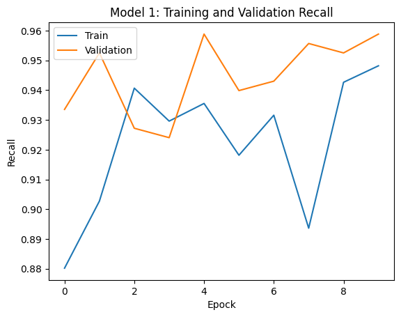

```python
plt.plot(history_1.history['recall']) #Complete the code to plot the train metrics
plt.plot(history_1.history['val_recall']) #Complete the code to plot the validation data metrics
plt.title('Model 1: Training and Validation Recall') #Complete the code to define the title for the plot
plt.ylabel('Recall') #Complete the code to define the label for the y-axis
plt.xlabel('Epock') #Complete the code to define the label for the x-axis
plt.legend(['Train', 'Validation'], loc='upper left')
plt.show()
```

```python
model_1_train_perf = model_performance_classification(model_1, X_train_normalized,y_train)

print("Train performance metrics")
print(model_1_train_perf)
```

```
104/104 ━━━━━━━━━━━━━━━━━━━━ 5s 29ms/step
Train performance metrics
   Accuracy    Recall  Precision  F1 Score
0  0.930909  0.880991   0.921119  0.898842
```

```
104/104 ━━━━━━━━━━━━━━━━━━━━ 3s 16ms/step
```

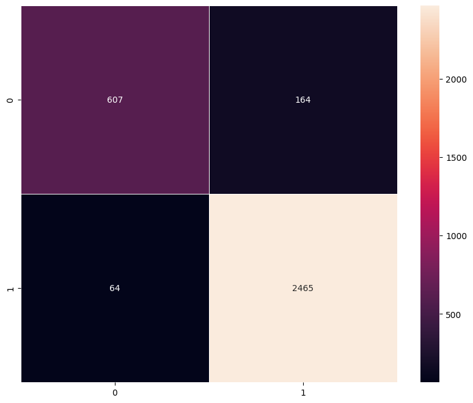

```python
plot_confusion_matrix(model_1,X_train_normalized,y_train)
```

```python
model_1_valid_perf = model_performance_classification(model_1, X_val_normalized,y_val)

print("Validation performance metrics")
print(model_1_valid_perf)
```

```
13/13 ━━━━━━━━━━━━━━━━━━━━ 0s 15ms/step
Validation performance metrics
   Accuracy    Recall  Precision  F1 Score
0  0.919903  0.875264   0.896007  0.884989
```

```
13/13 ━━━━━━━━━━━━━━━━━━━━ 0s 18ms/step
```

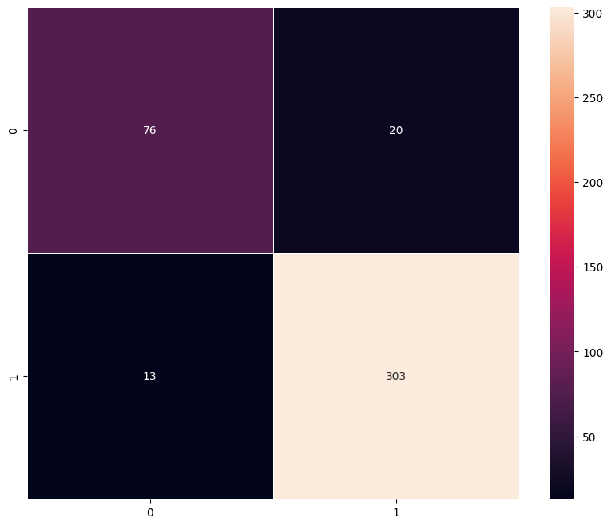

```python
plot_confusion_matrix(model_1,X_val_normalized,y_val)
```

### Visualizing the predictions

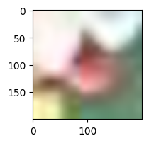

```
1/1 ━━━━━━━━━━━━━━━━━━━━ 0s 93ms/step
Predicted Label: 1
True Label: label    1
Name: 3836, dtype: int64
```

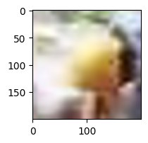

```
1/1 ━━━━━━━━━━━━━━━━━━━━ 0s 47ms/step
Predicted Label: 1
True Label: label    1
Name: 3029, dtype: int64
```

```python
# For index 12
plt.figure(figsize=(2,2))
plt.imshow(X_val[12])
plt.show()
prediction = model_1.predict(X_val_normalized[12].reshape(1, 200, 200, 3))
predicted_label = prediction[0][0]>0.5  # Extract the predicted class label
print('Predicted Label:', 1 if predicted_label else 0)
# Fix indexing issue in y_val
true_label = y_val.iloc[12]
print('True Label:', true_label)

# For index 33
plt.figure(figsize=(2,2))
plt.imshow(X_val[33])
plt.show()
prediction = model_1.predict(X_val_normalized[12].reshape(1, 200, 200, 3))
predicted_label = prediction[0][0]>0.5  # Extract the predicted class label
print('Predicted Label:', 1 if predicted_label else 0)
# Fix indexing issue in y_val
true_label = y_val.iloc[33]
print('True Label:', true_label)
```

## Model 1: Convolutional Neural Network from Scratch

> **Important validity note:** The current Model 1 results were generated with a ReLU activation in the final output layer. For binary classification with binary cross-entropy, the final layer should use a sigmoid activation. ReLU does not guarantee an output between 0 and 1, so the current results should be treated as provisional. Model 1 should be rebuilt and retrained with `Dense(1, activation="sigmoid")` before its results are used in the final model comparison.

## Model Architecture

Model 1 is a convolutional neural network built from scratch for binary helmet classification.

The model contains two principal components:

1. **Feature-extraction layers**, consisting of convolutional and pooling operations
2. **Classification layers**, consisting of flattened and fully connected dense layers

The model accepts images with the following input shape:

```
200 × 200 × 3
```

This represents images that are 200 pixels high, 200 pixels wide, and contain three RGB color channels.

### Convolutional and Pooling Layers

The first convolutional layer produces 16 feature maps:

```
(None, 200, 200, 16)
```

It uses 16 filters with a kernel size of `3 × 3`. The spatial dimensions remain `200 × 200` because `padding="same"` was used.

The first pooling layer reduces the spatial dimensions from:

```
200 × 200
```

to:

```
50 × 50
```

This reduces computational complexity while retaining prominent visual features.

The second convolutional layer increases the number of feature maps from 16 to 32:

```
(None, 50, 50, 32)
```

The second pooling layer reduces the spatial dimensions from:

```
50 × 50
```

to:

```
25 × 25
```

The third convolutional layer produces 64 feature maps:

```
(None, 25, 25, 64)
```

Increasing the number of filters allows the deeper layers to learn more complex visual patterns, such as edges, shapes, colors, head boundaries, and possible helmet features.

### Flattening and Classification

The final convolutional output contains:

$$ 25 \times 25 \times 64 = 40{,}000 $$

features.

The `Flatten` layer converts the feature maps into a one-dimensional vector containing 40,000 values.

The first dense layer reduces these features to four neurons:

```
(None, 4)
```

The final dense layer contains one neuron:

```
(None, 1)
```

The correct output layer for this binary classification problem is:

```
Dense(1, activation="sigmoid")
```

A sigmoid activation produces a probability between 0 and 1:

- Values greater than `0.5` are classified as label `1`, **With Helmet**
- Values at or below `0.5` are classified as label `0`, **Without Helmet**

## Number of Parameters

The model contains:

```
Total parameters:         183,593
Trainable parameters:     183,593
Non-trainable parameters:       0
```

All 183,593 parameters are trainable because this CNN was built from scratch rather than using pretrained weights.

The convolutional layers contain 23,584 parameters, while the first dense layer contains 160,004 parameters. Therefore, most of the model's parameters are concentrated in the dense classification layer.

## Training Configuration

The model was trained with:

- **Optimizer:** Adam
- **Learning rate:** `0.001`
- **Loss:** Binary cross-entropy
- **Batch size:** `32`
- **Training epochs:** `10`
- **Training-data shuffling:** Enabled
- **Tracked Keras metric:** Recall

With 3,300 training images and a batch size of 32, each epoch contained approximately 104 training steps.

> The numerical results below were produced by the original ReLU-output model and must be updated after retraining with a sigmoid output.

## Training History

### Loss

Training loss decreased from:

```
0.7070 in Epoch 1
```

to:

```
0.3071 in Epoch 10
```

This downward trend suggests that the model learned visual patterns from the training data.

Validation loss began at:

```
0.4046 in Epoch 1
```

and reached its lowest value of:

```
0.2131 in Epoch 6
```

The final validation loss was:

```
0.2928
```

The increase after Epoch 6 suggests that additional epochs did not consistently improve validation loss. This could represent normal training variability or the beginning of mild overfitting.

### Recall

Training recall increased overall from:

```
88.0% in Epoch 1
```

to:

```
94.8% in Epoch 10
```

Validation recall increased from:

```
93.4% in Epoch 1
```

to:

```
95.9% in Epoch 10
```

Both training and validation recall remained high but fluctuated across epochs.

Validation recall was frequently higher than training recall. This does not automatically indicate a problem. It can occur when the validation images are easier to classify or because training recall is accumulated while the model's weights are changing throughout an epoch.

## Training Performance

The provisional post-training metrics were:

| Metric | Training Result |
| --- | --- |
| Accuracy | 0.9309 |
| Macro recall | 0.8810 |
| Macro precision | 0.9211 |
| Macro F1-score | 0.8988 |

The model correctly classified approximately **93.1%** of the training images.

The provisional macro F1-score of approximately **89.9%** indicates a reasonably strong balance between precision and recall across both classes.

### Training Confusion Matrix

| Actual class | Predicted Without Helmet | Predicted With Helmet |
| --- | --- | --- |
| Without Helmet | 607 | 164 |
| With Helmet | 64 | 2,465 |

This means:

- **607** no-helmet images were classified correctly.
- **164** no-helmet images were incorrectly classified as helmeted.
- **64** helmet images were incorrectly classified as no-helmet.
- **2,465** helmet images were classified correctly.
- The model made **228 training errors**.
- The model made **3,072 correct training predictions**.

### Training Class-Specific Recall

Recall for the Without Helmet class was:

```
607 ÷ 771 = 78.7%
```

Recall for the With Helmet class was:

```
2,465 ÷ 2,529 = 97.5%
```

The model was considerably better at recognizing helmet images than no-helmet images.

## Validation Performance

The provisional validation metrics were:

| Metric | Validation Result |
| --- | --- |
| Accuracy | 0.9199 |
| Macro recall | 0.8753 |
| Macro precision | 0.8960 |
| Macro F1-score | 0.8850 |

The model correctly classified approximately **92.0%** of the validation images.

The provisional validation macro F1-score was approximately **88.5%**, suggesting reasonably balanced overall performance on unseen validation images.

### Validation Confusion Matrix

| Actual class | Predicted Without Helmet | Predicted With Helmet |
| --- | --- | --- |
| Without Helmet | 76 | 20 |
| With Helmet | 13 | 303 |

This means:

- **76** no-helmet images were classified correctly.
- **20** no-helmet images were incorrectly classified as helmeted.
- **13** helmet images were incorrectly classified as no-helmet.
- **303** helmet images were classified correctly.
- The model made **33 validation errors**.
- The model made **379 correct validation predictions**.

The validation accuracy can be verified as:

```
(76 + 303) ÷ 412 = 91.99%
```

### Validation Class-Specific Recall

Recall for the Without Helmet class was:

```
76 ÷ 96 = 79.2%
```

Recall for the With Helmet class was:

```
303 ÷ 316 = 95.9%
```

The model was substantially more effective at recognizing helmet images than no-helmet images.

## Safety Interpretation

The most consequential validation errors were the **20 workers without helmets who were incorrectly classified as wearing helmets**.

These errors represented:

$$ \frac{20}{96}\times100 \approx20.8\% $$

of the actual no-helmet validation images.

In a workplace-safety application, these false helmet detections are especially important because an unsafe worker could be incorrectly identified as compliant.

Although the model achieved approximately 92% validation accuracy, that overall result partially hides its weaker performance on the no-helmet class.

The class imbalance likely contributed to this result because the training data contains more than three times as many helmet images as no-helmet images.

## Training-to-Validation Generalization

| Metric | Training | Validation | Difference |
| --- | --- | --- | --- |
| Accuracy | 0.9309 | 0.9199 | 0.0110 |
| Macro recall | 0.8810 | 0.8753 | 0.0057 |
| Macro precision | 0.9211 | 0.8960 | 0.0251 |
| Macro F1-score | 0.8988 | 0.8850 | 0.0139 |

The training-validation differences were relatively small.

These gaps suggest that the provisional Model 1 generalized reasonably well and did not demonstrate severe overfitting during the 10 training epochs.

However, validation loss reached its lowest value in Epoch 6 and later increased. Early stopping could potentially preserve the weights associated with the lowest validation loss.

The generalization conclusion must be reevaluated after Model 1 is retrained with the correct sigmoid output activation.

## Keras Recall Compared with Macro Recall

The final Keras validation recall was:

```
0.9589
```

The validation performance table reported macro recall of:

```
0.8753
```

These values measure different concepts.

Keras recall treats label `1`, **With Helmet**, as the positive class:

```
Helmet recall = 303 ÷ 316 = 95.9%
```

Recall for the no-helmet class was:

```
No-helmet recall = 76 ÷ 96 = 79.2%
```

Macro recall gives both classes equal importance:

$$ \text{Macro Recall} = \frac{95.9\%+79.2\%}{2} \approx87.5\% $$

This explains why macro recall is lower than the Keras recall. Macro recall exposes the model's weaker performance on the minority no-helmet class.

## Example Predictions

The example validation images are blurred and contain limited visual detail. These images demonstrate the difficulty of classifying workers under poor image-quality conditions.

The second prediction must use validation image index `33`, matching the displayed image:

```
prediction = model_1.predict(
    X_val_normalized[33].reshape(1, 200, 200, 3)
)
```

Using index `12` for both predictions would incorrectly compare the prediction for one image with the true label of another image.

The correctness of the examples should be determined by comparing the printed predicted and true labels after rerunning the corrected model.

## Model 1 Conclusion

The provisional Model 1 results were:

- **Training accuracy:** 93.1%
- **Training macro F1-score:** 89.9%
- **Validation accuracy:** 92.0%
- **Validation macro F1-score:** 88.5%
- **Validation no-helmet recall:** 79.2%
- **Validation helmet recall:** 95.9%

The small training-validation gap suggests reasonable generalization. However, the model remained considerably better at recognizing helmet images than no-helmet images.

It incorrectly classified **20 of the 96 no-helmet validation images as helmet-compliant**, representing approximately **20.8% of the unsafe validation cases**.

These results must not be treated as final because the model used an incorrect ReLU output activation. Model 1 should be rebuilt and retrained with a sigmoid output before it is included in the final model comparison.

### Required Correction

Replace:

```
model_1.add(Dense(1, activation="relu"))
```

with:

```
model_1.add(Dense(1, activation="sigmoid"))
```

Then rerun:

1. Model initialization
2. Optimizer creation
3. Model compilation
4. Model summary
5. Training
6. Training curve
7. Training evaluation
8. Validation evaluation
9. Confusion matrices
10. Example predictions
11. Model comparison tables

### Concise Observation for the Presentation

Model 1's current results are provisional because the original model used a ReLU output instead of the sigmoid activation required for binary classification. The provisional run achieved 92.0% validation accuracy and an 88.5% macro F1-score, but it correctly detected only 79.2% of no-helmet images. Model 1 must be retrained with a sigmoid output before its results can be compared fairly with the VGG16 models.

## Model 2: Transfer Learning with VGG-16 (Base)

- We will be loading a pre-built architecture - **VGG16**, which was trained on the ImageNet dataset and is the runner-up in the ImageNet competition in 2014.
- For training VGG16, we will directly use the convolutional and pooling layers and freeze their weights i.e. no training will be done on them. For classification, we will add a Flatten and a single dense layer.

```python
vgg_model = VGG16(weights='imagenet',include_top=False,input_shape=(200,200,3)) #Complete the code to define the shape of the image
vgg_model.summary()
```

```
Downloading data from https://storage.googleapis.com/tensorflow/keras-applications/vgg16/vgg16_weights_tf_dim_ordering_tf_kernels_notop.h5
58889256/58889256 ━━━━━━━━━━━━━━━━━━━━ 0s 0us/step
```

```
Model: "vgg16"
```

```
┏━━━━━━━━━━━━━━━━━━━━━━━━━━━━━━━━━┳━━━━━━━━━━━━━━━━━━━━━━━━┳━━━━━━━━━━━━━━━┓
┃ Layer (type)                    ┃ Output Shape           ┃       Param # ┃
┡━━━━━━━━━━━━━━━━━━━━━━━━━━━━━━━━━╇━━━━━━━━━━━━━━━━━━━━━━━━╇━━━━━━━━━━━━━━━┩
│ input_layer_1 (InputLayer)      │ (None, 200, 200, 3)    │             0 │
├─────────────────────────────────┼────────────────────────┼───────────────┤
│ block1_conv1 (Conv2D)           │ (None, 200, 200, 64)   │         1,792 │
├─────────────────────────────────┼────────────────────────┼───────────────┤
│ block1_conv2 (Conv2D)           │ (None, 200, 200, 64)   │        36,928 │
├─────────────────────────────────┼────────────────────────┼───────────────┤
│ block1_pool (MaxPooling2D)      │ (None, 100, 100, 64)   │             0 │
├─────────────────────────────────┼────────────────────────┼───────────────┤
│ block2_conv1 (Conv2D)           │ (None, 100, 100, 128)  │        73,856 │
├─────────────────────────────────┼────────────────────────┼───────────────┤
│ block2_conv2 (Conv2D)           │ (None, 100, 100, 128)  │       147,584 │
├─────────────────────────────────┼────────────────────────┼───────────────┤
│ block2_pool (MaxPooling2D)      │ (None, 50, 50, 128)    │             0 │
├─────────────────────────────────┼────────────────────────┼───────────────┤
│ block3_conv1 (Conv2D)           │ (None, 50, 50, 256)    │       295,168 │
├─────────────────────────────────┼────────────────────────┼───────────────┤
│ block3_conv2 (Conv2D)           │ (None, 50, 50, 256)    │       590,080 │
├─────────────────────────────────┼────────────────────────┼───────────────┤
│ block3_conv3 (Conv2D)           │ (None, 50, 50, 256)    │       590,080 │
├─────────────────────────────────┼────────────────────────┼───────────────┤
│ block3_pool (MaxPooling2D)      │ (None, 25, 25, 256)    │             0 │
├─────────────────────────────────┼────────────────────────┼───────────────┤
│ block4_conv1 (Conv2D)           │ (None, 25, 25, 512)    │     1,180,160 │
├─────────────────────────────────┼────────────────────────┼───────────────┤
│ block4_conv2 (Conv2D)           │ (None, 25, 25, 512)    │     2,359,808 │
├─────────────────────────────────┼────────────────────────┼───────────────┤
│ block4_conv3 (Conv2D)           │ (None, 25, 25, 512)    │     2,359,808 │
├─────────────────────────────────┼────────────────────────┼───────────────┤
│ block4_pool (MaxPooling2D)      │ (None, 12, 12, 512)    │             0 │
├─────────────────────────────────┼────────────────────────┼───────────────┤
│ block5_conv1 (Conv2D)           │ (None, 12, 12, 512)    │     2,359,808 │
├─────────────────────────────────┼────────────────────────┼───────────────┤
│ block5_conv2 (Conv2D)           │ (None, 12, 12, 512)    │     2,359,808 │
├─────────────────────────────────┼────────────────────────┼───────────────┤
│ block5_conv3 (Conv2D)           │ (None, 12, 12, 512)    │     2,359,808 │
├─────────────────────────────────┼────────────────────────┼───────────────┤
│ block5_pool (MaxPooling2D)      │ (None, 6, 6, 512)      │             0 │
└─────────────────────────────────┴────────────────────────┴───────────────┘
```

```
 Total params: 14,714,688 (56.13 MB)
```

```
 Trainable params: 14,714,688 (56.13 MB)
```

```
 Non-trainable params: 0 (0.00 B)
```

```python
# Making all the layers of the VGG model non-trainable. i.e. freezing them
for layer in vgg_model.layers:
    layer.trainable = False
```

```python
model_2 = Sequential()

# Adding the convolutional part of the VGG16 model from above
model_2.add(vgg_model)

# Flattening the output of the VGG16 model because it is from a convolutional layer
model_2.add(Flatten())

# Adding a dense output layer
model_2.add(Dense(1, activation='sigmoid')) #Complete the code to define the number of neurons in the output layer.
```

```python
opt=Adam(learning_rate=0.001) #Complete the code to define the learning rate
# Compile model
model_2.compile(optimizer=opt, loss=keras.losses.BinaryCrossentropy(), metrics=["recall"]) #Complete the code to define the metrics
```

```python
# Generating the summary of the model
model_2.summary()
```

```
Model: "sequential_1"
```

```
┏━━━━━━━━━━━━━━━━━━━━━━━━━━━━━━━━━┳━━━━━━━━━━━━━━━━━━━━━━━━┳━━━━━━━━━━━━━━━┓
┃ Layer (type)                    ┃ Output Shape           ┃       Param # ┃
┡━━━━━━━━━━━━━━━━━━━━━━━━━━━━━━━━━╇━━━━━━━━━━━━━━━━━━━━━━━━╇━━━━━━━━━━━━━━━┩
│ vgg16 (Functional)              │ (None, 6, 6, 512)      │    14,714,688 │
├─────────────────────────────────┼────────────────────────┼───────────────┤
│ flatten_1 (Flatten)             │ (None, 18432)          │             0 │
├─────────────────────────────────┼────────────────────────┼───────────────┤
│ dense_2 (Dense)                 │ (None, 1)              │        18,433 │
└─────────────────────────────────┴────────────────────────┴───────────────┘
```

```
 Total params: 14,733,121 (56.20 MB)
```

```
 Trainable params: 18,433 (72.00 KB)
```

```
 Non-trainable params: 14,714,688 (56.13 MB)
```

```python
train_datagen = ImageDataGenerator()
```

```python
# Epochs
epochs = 10 #Complete the code to define the epochs
# Batch size
batch_size = 16 #Complete the code to define the batch size

history_2 = model_2.fit(train_datagen.flow(X_train_normalized,y_train,
                                      batch_size=batch_size,
                                      seed=42,
                                      shuffle=False),
                    epochs=epochs,
                    steps_per_epoch=X_train_normalized.shape[0] // batch_size,
                    validation_data=(X_val_normalized,y_val),
                    verbose=1)
```

```
206/206 ━━━━━━━━━━━━━━━━━━━━ 20s 92ms/step - loss: 0.3410 - recall: 0.9492 - val_loss: 0.2274 - val_recall: 0.9462
206/206 ━━━━━━━━━━━━━━━━━━━━ 2s 11ms/step - loss: 0.4804 - recall: 1.0000 - val_loss: 0.2449 - val_recall: 0.9082
206/206 ━━━━━━━━━━━━━━━━━━━━ 19s 92ms/step - loss: 0.2103 - recall: 0.9599 - val_loss: 0.2059 - val_recall: 0.9620
206/206 ━━━━━━━━━━━━━━━━━━━━ 2s 9ms/step - loss: 0.1000 - recall: 1.0000 - val_loss: 0.2104 - val_recall: 0.9778
206/206 ━━━━━━━━━━━━━━━━━━━━ 17s 81ms/step - loss: 0.1797 - recall: 0.9706 - val_loss: 0.2042 - val_recall: 0.9335
206/206 ━━━━━━━━━━━━━━━━━━━━ 2s 9ms/step - loss: 0.1393 - recall: 0.9231 - val_loss: 0.1987 - val_recall: 0.9430
206/206 ━━━━━━━━━━━━━━━━━━━━ 16s 79ms/step - loss: 0.1523 - recall: 0.9730 - val_loss: 0.2043 - val_recall: 0.9652
206/206 ━━━━━━━━━━━━━━━━━━━━ 2s 9ms/step - loss: 0.1032 - recall: 1.0000 - val_loss: 0.2006 - val_recall: 0.9557
206/206 ━━━━━━━━━━━━━━━━━━━━ 17s 82ms/step - loss: 0.1173 - recall: 0.9833 - val_loss: 0.1875 - val_recall: 0.9684
206/206 ━━━━━━━━━━━━━━━━━━━━ 2s 10ms/step - loss: 0.1475 - recall: 0.9091 - val_loss: 0.1854 - val_recall: 0.9620
```

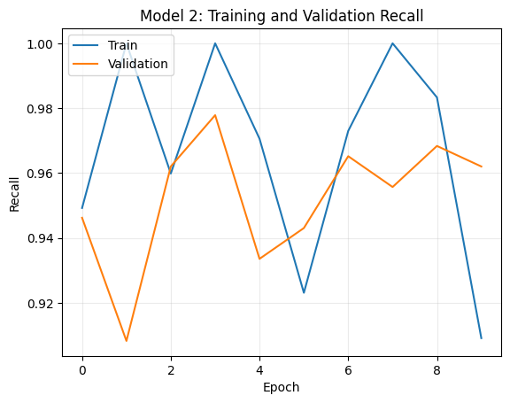

```python
plt.plot(history_2.history['recall']) #Complete the code to plot the train metrics
plt.plot(history_2.history["val_recall"]) #Complete the code to plot the validation data metrics
plt.title("Model 2: Training and Validation Recall") #Complete the code to define the title for the plot
plt.ylabel('Recall') #Complete the code to define the label for the y-axis
plt.xlabel('Epoch') #Complete the code to define the label for the x-axis
plt.legend(['Train', 'Validation'], loc='upper left')
plt.grid(alpha=0.25)
plt.show()
```

```python
model_2_train_perf = model_performance_classification(model_2,X_train_normalized,y_train)

print("Train performance metrics")
print(model_2_train_perf)
```

```
104/104 ━━━━━━━━━━━━━━━━━━━━ 16s 144ms/step
Train performance metrics
   Accuracy    Recall  Precision  F1 Score
0  0.974545  0.958599   0.969774  0.964034
```

```
104/104 ━━━━━━━━━━━━━━━━━━━━ 16s 144ms/step
```

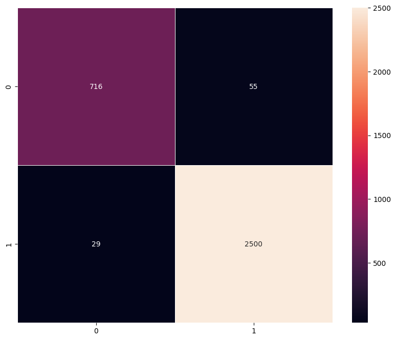

```python
plot_confusion_matrix(model_2,X_train_normalized,y_train)
```

```python
model_2_valid_perf = model_performance_classification(model_2, X_val_normalized,y_val)

print("Validation performance metrics")
print(model_2_valid_perf)
```

```
13/13 ━━━━━━━━━━━━━━━━━━━━ 2s 148ms/step
Validation performance metrics
   Accuracy    Recall  Precision  F1 Score
0  0.919903  0.871638   0.898727  0.884095
```

```
13/13 ━━━━━━━━━━━━━━━━━━━━ 2s 147ms/step
```

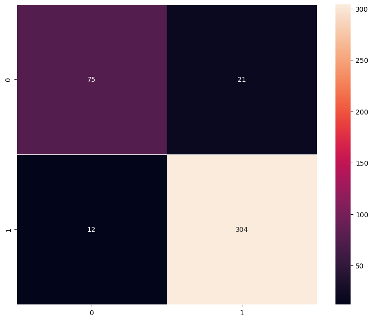

```python
plot_confusion_matrix(model_2,X_val_normalized,y_val)
```